# 공간통계를 위한 데이터 사이언스

단계구분도(choropleth) - `shapefile`

xwMOOC

Tidyverse Korea

2019-03-12

## 학습 목표

> - 단계구분도를 이해한다.
> - 대한민국인구를 단계구분도를 사용하여 지리정보 시각화한다.
> - 단계구분도 전용 R 팩키지와 그래프 문법 ggplot 팩키지로 지리정보를 시각화한다.

# 1 단계구분도(choropleth)

[단계구분도(Choropleth map)](https://en.wikipedia.org/wiki/Choropleth_map)는 주제도(thematic map)으로 인구밀도, 1인당 소득 같은 정보를 비례하여 음영처리나 패턴을 넣어 지도상에 표현하는 방식이다. 단계구분도 전용 `choroplethr` 팩키지와 그래픽 문법 범용 `ggplot` 팩키지를 사용하여 지리정보로 도식화한다.

# 2 2016년경 코드

## 2.1 전용 `choroplethr` 단계구분도

[choroplethr](https://cran.r-project.org/web/packages/choroplethr/index.html)[^1]은 R에서 단계구분도 생성을 간략화하려는 목적으로 개발되었다. 특히, [Administrative Level 1 Maps](https://cran.r-project.org/web/packages/choroplethr/vignettes/i-creating-admin1-maps.html) 소품문에 나와 있듯이, 인구조사 센서스 데이터가 있는 경우 쉽게 단계구분도를 쉽게 적용할 수 있다.

**사용시 주의사항**

- `admin1_choropleth` 함수는 지명은 `admin1.regions`에 **기재된 영문명** 을 사용한다.
- 단계구분도에 사용되는 값은 항상 변수명이 **`value`** 만 가능하다.

```r
##==========================================================================
## 팩키지 및 데이터 가져오기
##==========================================================================
library(choroplethr);library(choroplethrAdmin1);library(Kormaps);library(dplyr)
setwd("~/Dropbox/01_data_science") # 윈도우

# 지도데이터 가져오기
data(admin1.regions)
head(admin1.regions)

admin.all <- tbl_df(admin1.regions)
admin.kr <-  filter(admin.all, grepl("south korea", country))

admin1_map("south korea") # 가져온 데이터가 맞는 것인지 확인하는 명령어

# 시각화에 사용될 2010년 대한민국 인구센서스 데이터
df_korea_census <- korpopmap1@data
df_korea_census$name_eng <- tolower(df_korea_census$name_eng)

df_korea_census_mapdata <- df_korea_census %>%
  select(16,21)

names(df_korea_census_mapdata) <- c("region","value")

# choroplethrAdmin1 지도영문명 일치
# 서울 --> 서울특별시, 제주 --> 제주특별자치시, 세종시는 자료가 없음 (검은색 표시)

df_korea_census_mapdata$region[df_korea_census_mapdata$region=="seoul"] <- "seoul-teukbyeolsi"
df_korea_census_mapdata$region[df_korea_census_mapdata$region=="jeju"] <- "jeju-teukbyeoljachido"

##==========================================================================
## 대한민국 2010년 인구 단계구분도 지리정보 시각화
##==========================================================================

admin1_choropleth(country.name = "south korea",
                  df           = df_korea_census_mapdata,
                  title        = "2010 대한민국 인구",
                  legend       = "인구(단위:명)",
                  num_colors   = 1)
```

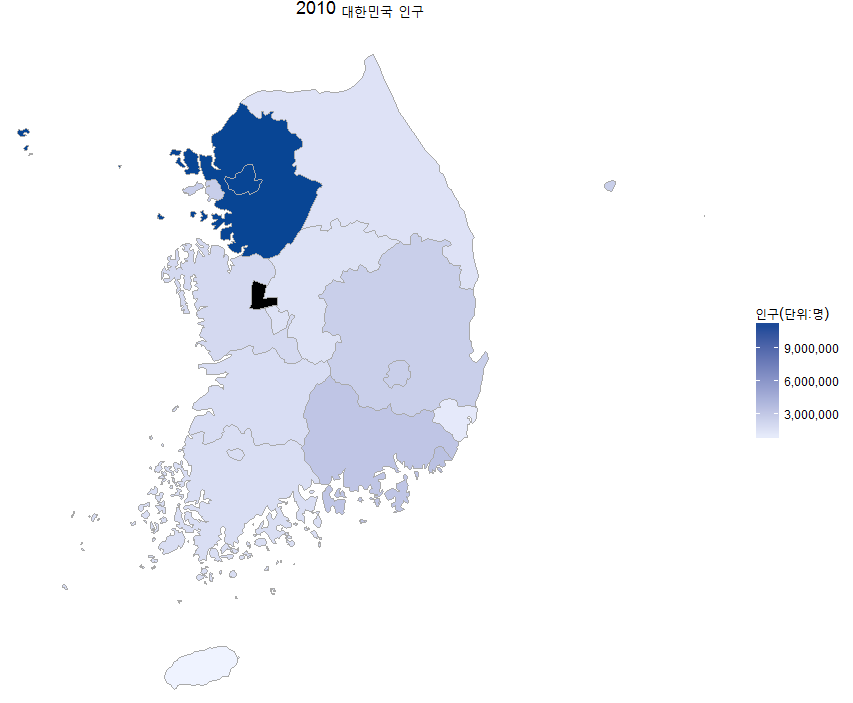

## 2.2 `ggplot` 팩키지 단계구분도 [^2]

단계구분도 전용 `choroplethr` 팩키지 대신 범용 `ggplot` 팩키지를 사용해서도 단계구분도를 수월하게 지리정보로 표현할 수 있다. 기본적으로 `.shp` 파일에 **id** 칼럼을 단계구분도에 표시되는 정보에 연결하는 것이 핵심이다. 따라서, `.shp` 파일에 **id** 칼럼을 확인하고, 단계구분도로 단계를 표시할 데이터프레임에 필히 **id** 칼럼을 포함하여 매칭될 수 있도록한다.

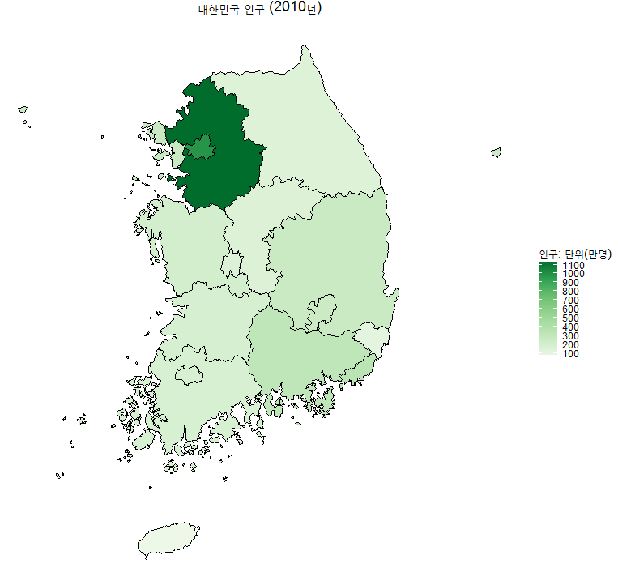

```r
##==========================================================================
## 팩키지 및 데이터 가져오기
##==========================================================================
# 라이브러리 및 작업 디렉토리 설정

library(choroplethr);library(choroplethrAdmin1);library(Kormaps);library(dplyr);library(ggmap);library(maptools);
library(RColorBrewer);library(scales)
setwd("~/Dropbox/01_data_science") # 윈도우

##==========================================================================
## .shp 파일 및 단계구분도 적용 데이터 가져오기
##==========================================================================
# `Kormaps` 팩키지 .shp 지도 사용 (2010 행정지도)

class(korpopmap1)
names(korpopmap1)

# 윈도우 인코딩문제 때문에 길어진 코드
tmp <- korpopmap1@data %>% select(21)
names(tmp) <- c("population")
tmp$population <- tmp$population / 10^4

# id 값을 .shp 파일과 동일하게 유지 (여기서 id는 각 시도에 대응)
kor.dat <- data.frame(NAME_1=korpopmap1$name_eng, id=korpopmap1$id)
kor.dat <- bind_cols(kor.dat, tmp)
kor.dat

# ggplot으로 시각화 위해 데이터프레임으로 변환
korea.shp.f <- fortify(korpopmap1, region = "id")

merge.shp.coef<-merge(korea.shp.f, kor.dat, by="id", all.x=TRUE)
korea.population.2010 <-merge.shp.coef[order(merge.shp.coef$order), ]

head(korea.population.2010)

##==========================================================================
## 대한민국 2010년 인구 단계구분도 지리정보 시각화
##==========================================================================
# 1 단계 : 시범 지리정보 도식화

ggplot() +
  geom_polygon(data = korea.population.2010,
               aes(x = long, y = lat, group = group, fill = population),
               color = "black", size = 0.25) +
  coord_map()

# 2 단계 : 배포 품질 도식화
ggplot() +
  geom_polygon(data = korea.population.2010,
               aes(x = long, y = lat, group = group, fill = population),
               color = "black", size = 0.25) +
  coord_map()+
  scale_fill_distiller(name="인구 : 단위(만명)", palette = "Greens", breaks = pretty_breaks(n = 10), direction = 1)+
  theme_nothing(legend = TRUE)+
  labs(title="대한민국 인구  (2010년)")
```

## 2.3 `ggmap` 팩키지 단계구분도 [^3]

전용 단계구분도 `choroplethr` 팩키지 및 그래픽 문법을 따르는 범용 그래픽 `ggplot` 팩키지를 사용하여 단계구분도를 작성해봤고, 그래픽 문법을 따르는 전용 지리정보 제공 `ggmap` 팩키지를 사용한다. 기본적으로 `.shp` 파일에 **id** 칼럼을 단계구분도에 표시되는 정보에 연결하는 것이 핵심은 동일하다. `.shp` 파일에 **id** 칼럼을 확인하고, 단계구분도로 단계를 표시할 데이터프레임에 필히 **id** 칼럼을 포함하여 매칭될 수 있도록 한다.

다만, `ggmap`을 사용할 경우 일반 지도 위에 `.shp` 파일을 올려 면(polygon)을 올릴 수 있다는 점에서 차이점이 생긴다.

데이터는 앞서 사용한 `Kormaps` 팩키지에 뽑아낸 2010년 인구통계총조사 자료를 `.shp` 파일에 사용한 동일한 데이터를 사용하고 이를 `ggmap`의 `qmap` 함수를 활용하여 단계구분도로 시각화한다. 1단계로 먼저 `.shp` 파일이 구글지도에 겹치는지 확인하고 나서, 2단계로 인구정보를 단계구분도로 도식화한다.

```r
# 1 단계
korea <- qmap("south korea", zoom=7)

korea +geom_polygon(aes(x=long,y=lat, group=group, alpha=0.25), data=korea.population.2010, fill='white') +
  geom_polygon(aes(x=long,y=lat, group=group), data=korea.population.2010, color='black', fill=NA)

# 2 단계: 연속형
korea +geom_polygon(aes(x=long,y=lat, group=group,  fill=population),
                    data=korea.population.2010, color="black") +
  scale_fill_gradient(low='white', high='red')


# 2 단계: 중간이 있는 연속형
korea + geom_polygon(aes(x=long,y=lat, group=group, fill=population), data=korea.population.2010, color='black') +
  scale_fill_distiller(palette='Spectral') + scale_alpha(range=c(0.5,0.5))
```

순서대로 단계구분도를 지도에 도식화하기 전에 `.shp` 파일에서 지도면 정보를 구글지도에 입히고 나서, 두가지 색상체계를 가지고 2010년 인구통계총조사 결과에 나온 인구정보를 지도에 도식화했다.

[figure not shown]

[^1]: [choroplethr: Simplify the Creation of Choropleth Maps in R](https://cran.r-project.org/web/packages/choroplethr/index.html)
[^2]: [Mapping with ggplot: Create a nice choropleth map in R](http://www.r-bloggers.com/mapping-with-ggplot-create-a-nice-choropleth-map-in-r/)
[^3]: [Plotting Choropleths from Shapefiles in R with ggmap – Toronto Neighbourhoods by Population](http://www.r-bloggers.com/plotting-choropleths-from-shapefiles-in-r-with-ggmap-toronto-neighbourhoods-by-population/)